# Reto Level 1 - Titanic

Christian Urcuqui

2019-07-17

# 1 Reto de aprendizaje

En el presente notebook se propone un taller que tiene como objetivo poner a prueba los conocimientos acerca de R para la resolución de preguntas de analítica de datos a partir un conjunto de datos que hace parte de un reto propuesto por la plataforma web Kaggle.

**Competencias del estudiante:**

- El lenguaje de programacion R y GitHub.
  - Aplicar los conceptos basicos de codificacion en R.
  - Explorar un data.frame en R.
  - Desarrollar plots básicos en R.
  - Manipular fechas y valores faltantes en R.
  - Aplicar funciones de R para la manipulación de datasets.

# 2 Descripción Titanic

[figure not shown]

En el siguiente enlace puede descargar el dataset de Titanic

```
https://raw.githubusercontent.com/urcuqui/Ciencia-de-datos-ICESI/master/posgrado/datasets/titanic/train_titanic.csv
```

[output not shown]

Se le pide un reporte en HTML donde se permita conocer el proceso y la aplicación de la exploración de datos y la respuesta a las siguientes preguntas:

## 2.1 Complejidad 1

- Explore el dataset e identifique las variables que presentan datos faltantes
- Transforme las variables a los siguientes tipos (solo si es necesario):
  - Name -> Character
  - Ticket -> Character
  - Cabin -> Factor
  - Embarked -> Factor
- Elimine los registros con datos faltantes
- (ggplot) utilice un diagrama que permita conocer cual es el número de registros (valores) más grande para la variable Survived (0,1)
- ¿Quien sobrevivió más, mujeres o hombres?

## 2.2 Complejidad 2

- (ggplot) ¿Existe algo particular entre la edad de las personas y la variable Survived?
- ¿Las familias númerosas sobreviven más?
- ¿Cuál fue el título de las personas que más y menos sobrevivieron en el titanic? **ayuda: con strsplit y un recorrido podras tener el título en el nombre de cada persona**
- Para este conjunto de datos, ¿qué tan cierto es que “Las mujeres y los niños primero…”?

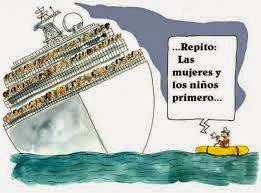